# Report

Maslo, Podkina, Lazarev

15 апреля 2017 г

## Отчет по второму заданию.

Исходные данные: информация о производстве оружия и количестве единиц сломанного оружия за каждый месяц каждым из кузнецов. Результат: решение о сотрудничестве с компанией Harpy/Westeros.

В качестве показателя, на основании которого будет приниматься итоговое решение о выборе компании, возьмем процент дефектных орудий для каждой произведенной партии.

Для дальнейшего анализа нам потребуется следующая информация: проценты дефектных орудий из произведенных партий для каждого кузнеца на каждый месяц после производства. Использовать будем пакет ggplot2, позволяющий изящно изобразить эту информацию в виде boxplot графика.

Cначала посмотрим на график по Harpy.

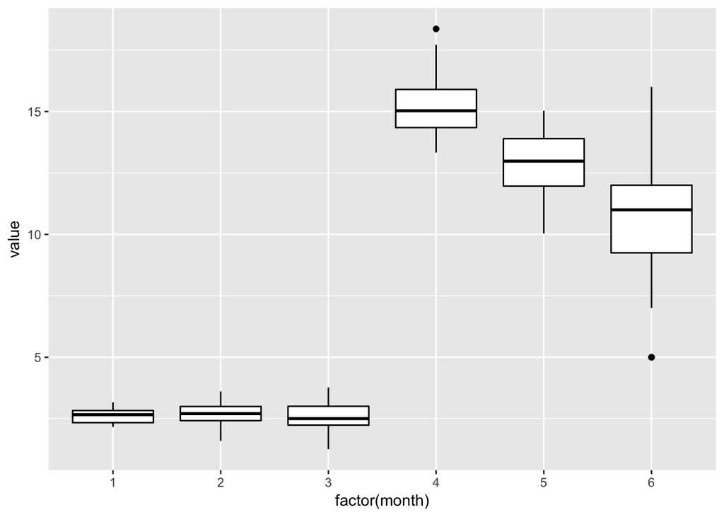

```r
plot_harpy <- ggplot(
  data = harpy_formatted,
  mapping = aes(factor(month), value))
plot_harpy <- plot_harpy + geom_boxplot(col = "black")
plot_harpy
```

Первые 3 месяца показывают относительно идентичную информацию, т.е. дефекты более менее одинаковые(различие наблюдаются в разнице между high и low значениями, high - low имеет линейную динамику роста). Но на 4-й месяц происходит резкое изменение, что говорит о том, что в 4-м месяце достигается глобальный максимум поломки орудий. Далее, наблюдается линейное убывание дефектов по среднему значению. Можно предположить, что этот тренд сохранится и больше локальных максимумов достигаться не будет.

Теперь перейдем к графику Westeros.

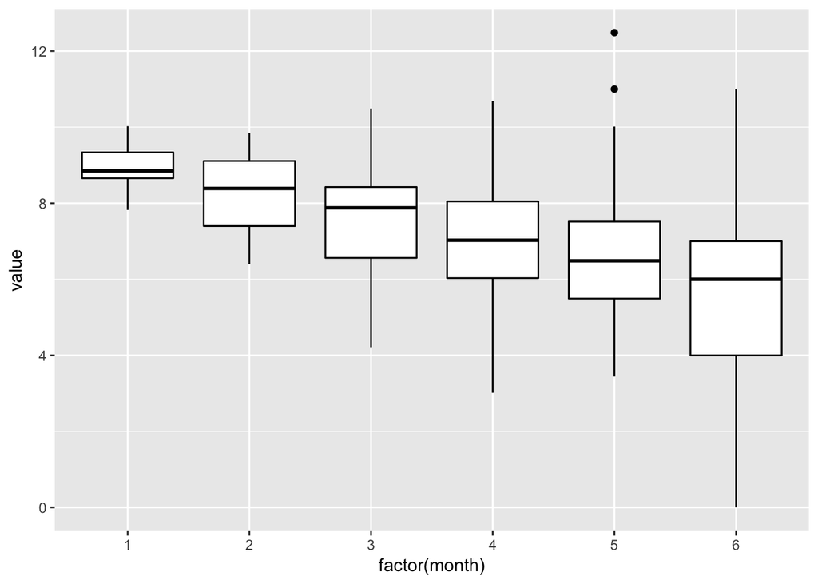

```r
plot_westeros <- ggplot(
  data = westeros_formatted,
  mapping = aes(factor(month), value))
plot_westeros <- plot_westeros + geom_boxplot(col = "black")
plot_westeros
```

Здесь мы видим следущее. Дефекты напоминают линейную функцию, убывающую с ростом месяца. В данном случае и среднее значение, и дисперсия показывает линейную динамику.

Можно выделить плюсы и минусы обеих компаний. Компания Harpy показывает гораздо более низкую дисперсию по проценту дефекта в первые 3 месяца по сравнению с компанией Westeros. Это позволит лучше прогнозировать поломки на первые 3 месяца после производства. С другой стороны наш горизонт планирования составляет 11 месяцев, что больше 3 месяцев. На этом промежутке преимущество по дисперсии стирается, так как на 4-6 месяцы дисперсия возрастает и становится вполне сравнимой с компанией Westeros. Компания Westeros в свою очередь имеет линейную динамику как по среднему значению, так и по дисперсии, что свидетельствует о большей вероятности сохранения “тренда”, то есть более валидному прогнозу на наш горизонт планирования. В качестве минуса Westeros можно отметить большое расстояние между high и low значениями. Несмотря на это привлекательность Westeros выше Harpy, поэтому наш выбор: Westeros.